# Exploring Sampling Workflow

1. Introduction
2. Step 1: Imports
3. Step 2: Data Exploration
4. Step 3: Statistical Tests
5. Step 4: Results and Evaluation
6. Considerations

# Introduction

For this project, I will engage in effective sampling of a dataset in order to make it easier to analyze.

For this workflow, I will simulate being a member of an analytics team for the Environmental Protection Agency. I have been assigned to analyze data on air quality with respect to carbon monoxide—a major air pollutant—and report my findings. The data utilized in this activity includes information from over 200 sites, identified by their state name, county name, city name, and local site name. I will use effective sampling within this dataset.

> - **The Purpose**: To demonstrate an active and working knowledge of proper sampling techniques.
> - **The Goal**: To analyze this dataset on air quality with respect to carbon monoxide and report my findings.

[figure not shown]

# Step 1: Imports

### Importing relevant packages

```python
# Libraries and packages imported
import numpy as np
import pandas as pd
import matplotlib.pyplot as plt
import statsmodels.api as sm
from scipy import stats
```

### Loading the dataset

```python
# Loading the data
epa_data = pd.read_csv("c4_epa_air_quality.csv", index_col = 0)
```

# Step 2: Data Exploration

### Examing the data

```python
# Quickly exploring the first 10 rows of the dataset
epa_data.head(10)
```

|  | date_local | state_name | county_name | city_name | local_site_name | parameter_name | units_of_measure | arithmetic_mean | aqi |
| --- | --- | --- | --- | --- | --- | --- | --- | --- | --- |
| 0 | 2018-01-01 | Arizona | Maricopa | Buckeye | BUCKEYE | Carbon monoxide | Parts per million | 0.473684 | 7 |
| 1 | 2018-01-01 | Ohio | Belmont | Shadyside | Shadyside | Carbon monoxide | Parts per million | 0.263158 | 5 |
| 2 | 2018-01-01 | Wyoming | Teton | Not in a city | Yellowstone National Park - Old Faithful Snow ... | Carbon monoxide | Parts per million | 0.111111 | 2 |
| 3 | 2018-01-01 | Pennsylvania | Philadelphia | Philadelphia | North East Waste (NEW) | Carbon monoxide | Parts per million | 0.300000 | 3 |
| 4 | 2018-01-01 | Iowa | Polk | Des Moines | CARPENTER | Carbon monoxide | Parts per million | 0.215789 | 3 |
| 5 | 2018-01-01 | Hawaii | Honolulu | Not in a city | Kapolei | Carbon monoxide | Parts per million | 0.994737 | 14 |
| 6 | 2018-01-01 | Hawaii | Honolulu | Not in a city | Kapolei | Carbon monoxide | Parts per million | 0.200000 | 2 |
| 7 | 2018-01-01 | Pennsylvania | Erie | Erie | NaN | Carbon monoxide | Parts per million | 0.200000 | 2 |
| 8 | 2018-01-01 | Hawaii | Honolulu | Honolulu | Honolulu | Carbon monoxide | Parts per million | 0.400000 | 5 |
| 9 | 2018-01-01 | Colorado | Larimer | Fort Collins | Fort Collins - CSU - S. Mason | Carbon monoxide | Parts per million | 0.300000 | 6 |

### Generating a table of descriptive statistics

```python
# Displaying descriptive statistics including all cloumns of the input
epa_data.describe(include='all')
```

|  | date_local | state_name | county_name | city_name | local_site_name | parameter_name | units_of_measure | arithmetic_mean | aqi |
| --- | --- | --- | --- | --- | --- | --- | --- | --- | --- |
| count | 260 | 260 | 260 | 260 | 257 | 260 | 260 | 260.000000 | 260.000000 |
| unique | 1 | 52 | 149 | 190 | 253 | 1 | 1 | NaN | NaN |
| top | 2018-01-01 | California | Los Angeles | Not in a city | Kapolei | Carbon monoxide | Parts per million | NaN | NaN |
| freq | 260 | 66 | 14 | 21 | 2 | 260 | 260 | NaN | NaN |
| mean | NaN | NaN | NaN | NaN | NaN | NaN | NaN | 0.403169 | 6.757692 |
| std | NaN | NaN | NaN | NaN | NaN | NaN | NaN | 0.317902 | 7.061707 |
| min | NaN | NaN | NaN | NaN | NaN | NaN | NaN | 0.000000 | 0.000000 |
| 25% | NaN | NaN | NaN | NaN | NaN | NaN | NaN | 0.200000 | 2.000000 |
| 50% | NaN | NaN | NaN | NaN | NaN | NaN | NaN | 0.276315 | 5.000000 |
| 75% | NaN | NaN | NaN | NaN | NaN | NaN | NaN | 0.516009 | 9.000000 |
| max | NaN | NaN | NaN | NaN | NaN | NaN | NaN | 1.921053 | 50.000000 |

**Observations**:

> - Based on the preceding table of descriptive statistics, the mean value of the Air Quality Index `aqi` field is `6.757692`.
> - This value will be compared to the mean value after sampling with replacement later within this notebook.
> - The count value for the `aqi` column is 260, indicating that there are 260 AQI measurements represented in this dataset.

[figure not shown]

# Step 3: Statistical Tests

### Sampling with replacement

> - First, I'll name a new variable `sampled_data`, then use the `sample()` dataframe method to draw `50` samples from `epa_data`.
> - I'll set `replace` equal to `True` to specify sampling with replacement.
> - For `random_state`, I'll choose an arbitrary number for random seed and make that arbitrary number `42`.

```python
# Random sampling from `epa_data`
sampled_data = epa_data.sample(n=50, replace=True, random_state=42)
```

```python
# Displaying the first 10 rows
sampled_data.head(10)
```

|  | date_local | state_name | county_name | city_name | local_site_name | parameter_name | units_of_measure | arithmetic_mean | aqi |
| --- | --- | --- | --- | --- | --- | --- | --- | --- | --- |
| 102 | 2018-01-01 | Texas | Harris | Houston | Clinton | Carbon monoxide | Parts per million | 0.157895 | 2 |
| 106 | 2018-01-01 | California | Imperial | Calexico | Calexico-Ethel Street | Carbon monoxide | Parts per million | 1.183333 | 26 |
| 71 | 2018-01-01 | Alabama | Jefferson | Birmingham | Arkadelphia/Near Road | Carbon monoxide | Parts per million | 0.200000 | 2 |
| 188 | 2018-01-01 | Arizona | Maricopa | Tempe | Diablo | Carbon monoxide | Parts per million | 0.542105 | 10 |
| 20 | 2018-01-01 | Virginia | Roanoke | Vinton | East Vinton Elementary School | Carbon monoxide | Parts per million | 0.100000 | 1 |
| 102 | 2018-01-01 | Texas | Harris | Houston | Clinton | Carbon monoxide | Parts per million | 0.157895 | 2 |
| 121 | 2018-01-01 | North Carolina | Mecklenburg | Charlotte | Garinger High School | Carbon monoxide | Parts per million | 0.200000 | 2 |
| 214 | 2018-01-01 | Florida | Broward | Davie | Daniela Banu NCORE | Carbon monoxide | Parts per million | 0.273684 | 5 |
| 87 | 2018-01-01 | California | Humboldt | Eureka | Jacobs | Carbon monoxide | Parts per million | 0.393750 | 5 |
| 99 | 2018-01-01 | California | Santa Barbara | Goleta | Goleta | Carbon monoxide | Parts per million | 0.222222 | 3 |

**Observations**:

> - Sampling with replacement is random, allowing sampling units to occur more than once. Row index `102` just happened to be sampled more than once.
> - The `random_state` parameter allows for the reproduction of the exact sample (i.e., the same set of numbers). This means that the same rows in the dataset will be sampled with replacement each time the command is run.

### Computing the mean value from the `aqi` column

> - Next, I'll compute the mean value from the `aqi` column in `sampled_data` and assign the value to the variable `sample_mean`.

```python
# Sampling the mean value from the `aqi` column in sampled_data
sample_mean = sampled_data['aqi'].mean()
sample_mean
```

```
5.54
```

**Observations**:

> - Due to sample variability, the sample mean (`sample_mean`) is usually not the same as the population mean (`population_mean`).
> - In this case, the sample mean is a point estimate of the population mean based on a random sample of 50 AQI values rather than the 260 AQI values from the original population in `epa_data`.

### Applying the central limit theorem

> - Imagine taking `10,000` random samples of `50` AQI values and computing the mean for each sample. According to the **central limit theorem**, the mean of a sampling distribution should be roughly equal to the population mean. I'll complete the following steps to compute the mean of the sampling distribution with `10,000` samples.
> - I'll create an empty list and assign it to a variable called `estimate_list`.
> - I'll then iterate through a `for` loop `10,000` times. To do this, I'll make sure to utilize the `range()` function to generate a sequence of numbers from `0` to `9,999`.
> - In each iteration of the loop, I'll use the `sample()` function to take a random sample (with replacement) of `50` AQI values from the population. I will not set the `random_state` to a value.
> - I'll use the list `append()` function to add the value of the sample `mean` to each item in the list.

[figure not shown]

```python
# Applying the central limit theorem
estimate_list = []
for i in range(10000):
    estimate_list.append(epa_data['aqi'].sample(n=50,replace=True).mean())
```

### Creating a new dataframe

Next, Ill create a new dataframe from the list of `10,000` estimates and name the new variable `estimate_df`.

```python
estimate_df = pd.DataFrame(data={'estimate': estimate_list})
estimate_df
```

|  | estimate |
| --- | --- |
| 0 | 5.30 |
| 1 | 8.20 |
| 2 | 5.34 |
| 3 | 6.24 |
| 4 | 6.30 |
| ... | ... |
| 9995 | 5.98 |
| 9996 | 5.90 |
| 9997 | 7.18 |
| 9998 | 6.44 |
| 9999 | 6.40 |

10000 rows × 1 columns

#### Computing the `mean()` of the sampling distribution of `10,000` random samples stored in a new variable `mean_sample_means`

```python
# Evaluating the `10,000` random samples mean
mean_sample_means = estimate_df['estimate'].mean()
mean_sample_means
```

```
6.7579
```

**Observations**:

> - The mean for the sampling distribution of the `10,000` random samples will vary as `random_state` was not assigned a value.

**How the central limit theorem and random sampling (with replacement) are related**:

> - Random sampling with replacement is related to the central limit theorem because it means you are drawing observations independently from a population. The central limit theorem states that if a sample size is large enough and the observations are drawn independently—or with replacement—the sampling distribution of the sample mean is approximately the normal distribution. Furthermore, the mean parameter is the population mean and the standard deviation parameter is the standard error.

### Outputting the distribution using a histogram

> - Next, I'll ouput the distribution of these estimates using a histogram as this provides an idea of the sampling distribution.

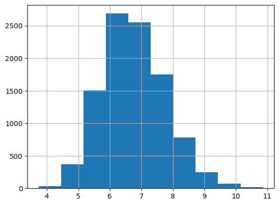

```python
# Displaying the sampling distribution
estimate_df['estimate'].hist()
```

### Calculating the standard error

> - Next, I'll calculate the standard error of the mean AQI using the initial sample of `50`. The **standard error** of a statistic measures the sample-to-sample variability of the sample statistic. It provides a numerical measure of sampling variability and answers the question: How far is a statistic based on one particular sample from the actual value of the statistic?

```python
# Calculating the standard error
standard_error = sampled_data['aqi'].std() / np.sqrt(len(sampled_data))
standard_error
```

```
0.7413225908290327
```

# Step 4: Results and Evaluation

### Visualizing the relationship between the sampling and normal distributions

> - Next, I'll visualize the relationship between my sampling distribution of `10,000` estimates and the normal distribution. The following code overlays the density curve of the normal distribution described in the theorem on top of the histogram of the sampling distribution obtained by repeated sampling. The solid magenta line in the graph is the population mean, the blue dotted line is the mean of the `10,000` sample means, and the red dashed line is the mean of the first random sample of `50`.

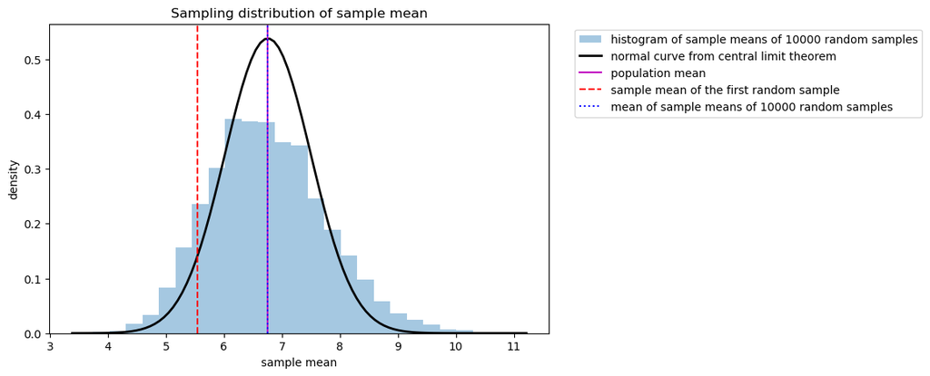

```python
 # Generating a grid of 100 values from xmin to xmax.
plt.figure(figsize=(8,5))
plt.hist(estimate_df['estimate'], bins=25, density=True, alpha=0.4, label = "histogram of sample means of 10000 random samples")
xmin, xmax = plt.xlim()
x = np.linspace(xmin, xmax, 100) # generate a grid of 100 values from xmin to xmax.
p = stats.norm.pdf(x, population_mean, standard_error)
plt.plot(x, p, 'k', linewidth=2, label = 'normal curve from central limit theorem')
plt.axvline(x=population_mean, color='m', linestyle = 'solid', label = 'population mean')
plt.axvline(x=sample_mean, color='r', linestyle = '--', label = 'sample mean of the first random sample')
plt.axvline(x=mean_sample_means, color='b', linestyle = ':', label = 'mean of sample means of 10000 random samples')
plt.title("Sampling distribution of sample mean")
plt.xlabel('sample mean')
plt.ylabel('density')
plt.legend(bbox_to_anchor=(1.04,1));
```

**Observations**:

Insights gained from the preceding sampling distribution:

> - 1. The histogram of the sampling distribution is well-approximated by the normal distribution described by the central limit theorem.
> - 2. The estimate based on one particular sample (red dashed line) is off-center. This is expected due to sampling variability. The red dashed line would be in a different location if `epa_data.sample(n=50, replace=True, random_state=42)` had a different value for `random_state`.
> - 3. The population mean (purple solid line) and the mean of the sample means (blue dotted line) overlap, meaning that they are essentially equal to each other.

# Considerations

**Takeaways**:

> - Sampling with replacement on a dataset leads to duplicate rows.
> - Sample means are different from population means due to sampling variability.
> - The central limit theorem helps describe the sampling distribution of the sample mean for many different types of datasets.

**Findings to share with others**:

> - The mean AQI in a sample of 50 observations was below 100 in a statistically significant sense (at least 2–3 standard errors away). For reference, AQI values at or below 100 are generally thought of as satisfactory.
> - This notebook did not examine values outside the "satisfactory" range so analysis should be done to investigate unhealthy AQI values.

**Communication to Stakeholders**:

> - Carbon monoxide levels are satisfactory in general.
> - Funding should be allocated to further investigate regions with unhealthy levels of carbon monoxide and improve the conditions in those regions.